# Risk Factor Analysis

## Outcome Variable

**Outcome Variable:** whz

## Predictor Variables

**Intervention Variable:** impfloor

**Adjustment Set:**

- arm
- sex
- W_mage
- meducyrs
- feducyrs
- hhwealth_quart
- hfoodsec
- W_mhtcm
- W_nrooms
- W_nchldlt5
- W_parity
- impsan
- safeh20
- delta_W_mage
- delta_meducyrs
- delta_feducyrs
- delta_hhwealth_quart
- delta_hfoodsec
- delta_W_mhtcm
- delta_W_nrooms
- delta_W_nchldlt5
- delta_W_parity
- delta_impsan
- delta_safeh20

## Stratifying Variables

The analysis was stratified on these variable(s):

- agecat
- studyid
- country

## Data Summary

| agecat | studyid | country | impfloor | n_cell | n |
| --- | --- | --- | --- | --- | --- |
| Birth | ki0047075b-MAL-ED | BANGLADESH | 1 | 205 | 222 |
| Birth | ki0047075b-MAL-ED | BANGLADESH | 0 | 17 | 222 |
| Birth | ki0047075b-MAL-ED | BRAZIL | 1 | 165 | 167 |
| Birth | ki0047075b-MAL-ED | BRAZIL | 0 | 2 | 167 |
| Birth | ki0047075b-MAL-ED | INDIA | 1 | 178 | 188 |
| Birth | ki0047075b-MAL-ED | INDIA | 0 | 10 | 188 |
| Birth | ki0047075b-MAL-ED | NEPAL | 1 | 64 | 159 |
| Birth | ki0047075b-MAL-ED | NEPAL | 0 | 95 | 159 |
| Birth | ki0047075b-MAL-ED | PERU | 1 | 54 | 252 |
| Birth | ki0047075b-MAL-ED | PERU | 0 | 198 | 252 |
| Birth | ki0047075b-MAL-ED | SOUTH AFRICA | 1 | 196 | 216 |
| Birth | ki0047075b-MAL-ED | SOUTH AFRICA | 0 | 20 | 216 |
| Birth | ki0047075b-MAL-ED | TANZANIA, UNITED REPUBLIC OF | 1 | 7 | 113 |
| Birth | ki0047075b-MAL-ED | TANZANIA, UNITED REPUBLIC OF | 0 | 106 | 113 |
| Birth | ki1000108-CMC-V-BCS-2002 | INDIA | 1 | 71 | 71 |
| Birth | ki1000108-CMC-V-BCS-2002 | INDIA | 0 | 0 | 71 |
| Birth | ki1000108-IRC | INDIA | 1 | 253 | 253 |
| Birth | ki1000108-IRC | INDIA | 0 | 0 | 253 |
| Birth | ki1017093-NIH-Birth | BANGLADESH | 1 | 24 | 28 |
| Birth | ki1017093-NIH-Birth | BANGLADESH | 0 | 4 | 28 |
| Birth | ki1017093c-NIH-Crypto | BANGLADESH | 1 | 18 | 23 |
| Birth | ki1017093c-NIH-Crypto | BANGLADESH | 0 | 5 | 23 |
| Birth | ki1114097-CONTENT | PERU | 1 | 2 | 2 |
| Birth | ki1114097-CONTENT | PERU | 0 | 0 | 2 |
| Birth | kiGH5241-JiVitA-3 | BANGLADESH | 1 | 925 | 15666 |
| Birth | kiGH5241-JiVitA-3 | BANGLADESH | 0 | 14741 | 15666 |
| Birth | kiGH5241-JiVitA-4 | BANGLADESH | 1 | 58 | 683 |
| Birth | kiGH5241-JiVitA-4 | BANGLADESH | 0 | 625 | 683 |
| 6 months | ki0047075b-MAL-ED | BANGLADESH | 1 | 221 | 240 |
| 6 months | ki0047075b-MAL-ED | BANGLADESH | 0 | 19 | 240 |

[output cut: 62 more lines]

The following strata were considered:

- agecat: 24 months, studyid: ki0047075b-MAL-ED, country: BANGLADESH
- agecat: 24 months, studyid: ki0047075b-MAL-ED, country: BRAZIL
- agecat: 24 months, studyid: ki0047075b-MAL-ED, country: INDIA
- agecat: 24 months, studyid: ki0047075b-MAL-ED, country: NEPAL
- agecat: 24 months, studyid: ki0047075b-MAL-ED, country: PERU
- agecat: 24 months, studyid: ki0047075b-MAL-ED, country: SOUTH AFRICA
- agecat: 24 months, studyid: ki0047075b-MAL-ED, country: TANZANIA, UNITED REPUBLIC OF
- agecat: 24 months, studyid: ki1000108-CMC-V-BCS-2002, country: INDIA
- agecat: 24 months, studyid: ki1000108-IRC, country: INDIA
- agecat: 24 months, studyid: ki1017093-NIH-Birth, country: BANGLADESH
- agecat: 24 months, studyid: ki1017093b-PROVIDE, country: BANGLADESH
- agecat: 24 months, studyid: ki1017093c-NIH-Crypto, country: BANGLADESH
- agecat: 24 months, studyid: ki1113344-GMS-Nepal, country: NEPAL
- agecat: 24 months, studyid: ki1114097-CONTENT, country: PERU
- agecat: 24 months, studyid: kiGH5241-JiVitA-3, country: BANGLADESH
- agecat: 24 months, studyid: kiGH5241-JiVitA-4, country: BANGLADESH
- agecat: 6 months, studyid: ki0047075b-MAL-ED, country: BANGLADESH
- agecat: 6 months, studyid: ki0047075b-MAL-ED, country: BRAZIL
- agecat: 6 months, studyid: ki0047075b-MAL-ED, country: INDIA
- agecat: 6 months, studyid: ki0047075b-MAL-ED, country: NEPAL
- agecat: 6 months, studyid: ki0047075b-MAL-ED, country: PERU
- agecat: 6 months, studyid: ki0047075b-MAL-ED, country: SOUTH AFRICA
- agecat: 6 months, studyid: ki0047075b-MAL-ED, country: TANZANIA, UNITED REPUBLIC OF
- agecat: 6 months, studyid: ki1000108-CMC-V-BCS-2002, country: INDIA
- agecat: 6 months, studyid: ki1000108-IRC, country: INDIA
- agecat: 6 months, studyid: ki1017093-NIH-Birth, country: BANGLADESH
- agecat: 6 months, studyid: ki1017093b-PROVIDE, country: BANGLADESH
- agecat: 6 months, studyid: ki1017093c-NIH-Crypto, country: BANGLADESH
- agecat: 6 months, studyid: ki1113344-GMS-Nepal, country: NEPAL
- agecat: 6 months, studyid: ki1114097-CONTENT, country: PERU
- agecat: 6 months, studyid: kiGH5241-JiVitA-3, country: BANGLADESH
- agecat: 6 months, studyid: kiGH5241-JiVitA-4, country: BANGLADESH
- agecat: Birth, studyid: ki0047075b-MAL-ED, country: BANGLADESH
- agecat: Birth, studyid: ki0047075b-MAL-ED, country: BRAZIL
- agecat: Birth, studyid: ki0047075b-MAL-ED, country: INDIA
- agecat: Birth, studyid: ki0047075b-MAL-ED, country: NEPAL
- agecat: Birth, studyid: ki0047075b-MAL-ED, country: PERU
- agecat: Birth, studyid: ki0047075b-MAL-ED, country: SOUTH AFRICA
- agecat: Birth, studyid: ki0047075b-MAL-ED, country: TANZANIA, UNITED REPUBLIC OF
- agecat: Birth, studyid: ki1000108-CMC-V-BCS-2002, country: INDIA
- agecat: Birth, studyid: ki1000108-IRC, country: INDIA
- agecat: Birth, studyid: ki1017093-NIH-Birth, country: BANGLADESH
- agecat: Birth, studyid: ki1017093c-NIH-Crypto, country: BANGLADESH
- agecat: Birth, studyid: ki1114097-CONTENT, country: PERU
- agecat: Birth, studyid: kiGH5241-JiVitA-3, country: BANGLADESH
- agecat: Birth, studyid: kiGH5241-JiVitA-4, country: BANGLADESH

### Dropped Strata

Some strata were dropped due to rare outcomes:

- agecat: Birth, studyid: ki0047075b-MAL-ED, country: BRAZIL
- agecat: Birth, studyid: ki1000108-CMC-V-BCS-2002, country: INDIA
- agecat: Birth, studyid: ki1000108-IRC, country: INDIA
- agecat: Birth, studyid: ki1017093-NIH-Birth, country: BANGLADESH
- agecat: Birth, studyid: ki1114097-CONTENT, country: PERU
- agecat: 6 months, studyid: ki0047075b-MAL-ED, country: BRAZIL
- agecat: 6 months, studyid: ki1000108-CMC-V-BCS-2002, country: INDIA
- agecat: 6 months, studyid: ki1000108-IRC, country: INDIA
- agecat: 24 months, studyid: ki0047075b-MAL-ED, country: BRAZIL
- agecat: 24 months, studyid: ki1000108-CMC-V-BCS-2002, country: INDIA
- agecat: 24 months, studyid: ki1000108-IRC, country: INDIA

## Methods Detail

We’re interested in the causal parameters $E[Y_a]$ for all values of $a \in \mathcal{A}$. These parameters represent the mean outcome if, possibly contrary to fact, we intervened to set all units to have $A=a$. Under the randomization and positivity assumptions, these are identified by the statistical parameters $\psi_a=E_W[E_{Y|A,W}(Y|A=a,W)]$. In addition, we’re interested in the mean of $Y$, $E[Y]$ under no intervention (the observed mean). We will estimate these parameters by using SuperLearner to fit the relevant likelihood factors – $E_{Y|A,W}(Y|A=a,W)$ and $p(A=a|W)$, and then updating our likelihood fit using a joint TMLE.

For unadjusted analyses ($W=\{\}$), initial likelihoods were estimated using Lrnr_glm to estimate the simple $E(Y|A)$ and Lrnr_mean to estimate $p(A)$. For adjusted analyses, a small library containing Lrnr_glmnet, Lrnr_xgboost, and Lrnr_mean was used.

Having estimated these parameters, we will then use the delta method to estimate relative risks and attributable risks relative to a prespecified baseline level of $A$.

# Results Detail

## Results Plots

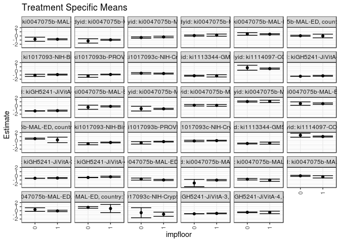

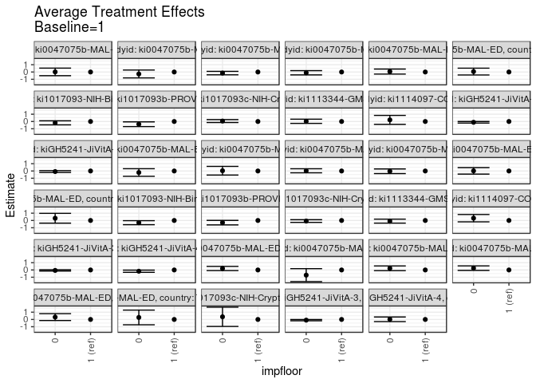

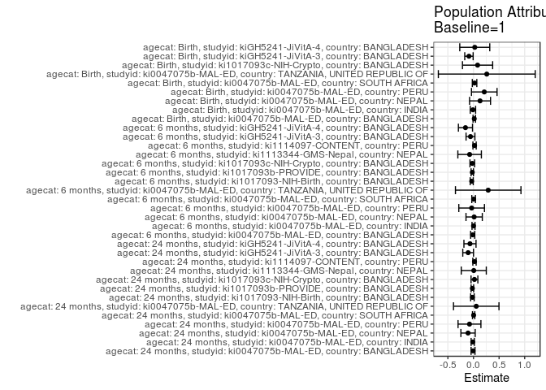

## Results Table

### Parameter: TSM

| agecat | studyid | country | intervention_level | baseline_level | estimate | ci_lower | ci_upper |
| --- | --- | --- | --- | --- | --- | --- | --- |
| Birth | ki0047075b-MAL-ED | BANGLADESH | 1 | NA | -1.0052101 | -1.1556887 | -0.8547316 |
| Birth | ki0047075b-MAL-ED | BANGLADESH | 0 | NA | -0.8022203 | -1.0483869 | -0.5560537 |
| Birth | ki0047075b-MAL-ED | INDIA | 1 | NA | -1.0427833 | -1.1834230 | -0.9021436 |
| Birth | ki0047075b-MAL-ED | INDIA | 0 | NA | -1.7534751 | -2.6323286 | -0.8746215 |
| Birth | ki0047075b-MAL-ED | NEPAL | 1 | NA | -1.0644147 | -1.3305291 | -0.7983003 |
| Birth | ki0047075b-MAL-ED | NEPAL | 0 | NA | -0.8343519 | -1.0158285 | -0.6528753 |
| Birth | ki0047075b-MAL-ED | PERU | 1 | NA | -0.2488225 | -0.5312838 | 0.0336388 |
| Birth | ki0047075b-MAL-ED | PERU | 0 | NA | 0.0027841 | -0.1233701 | 0.1289383 |
| Birth | ki0047075b-MAL-ED | SOUTH AFRICA | 1 | NA | -0.0282662 | -0.1941834 | 0.1376510 |
| Birth | ki0047075b-MAL-ED | SOUTH AFRICA | 0 | NA | 0.2968161 | -0.1455650 | 0.7391972 |
| Birth | ki0047075b-MAL-ED | TANZANIA, UNITED REPUBLIC OF | 1 | NA | 0.5485714 | -0.4383071 | 1.5354500 |
| Birth | ki0047075b-MAL-ED | TANZANIA, UNITED REPUBLIC OF | 0 | NA | 0.8251887 | 0.6170513 | 1.0333260 |
| Birth | ki1017093c-NIH-Crypto | BANGLADESH | 1 | NA | -0.8305556 | -1.3428871 | -0.3182240 |
| Birth | ki1017093c-NIH-Crypto | BANGLADESH | 0 | NA | -0.4640000 | -1.6852927 | 0.7572927 |
| Birth | kiGH5241-JiVitA-3 | BANGLADESH | 1 | NA | -0.6345912 | -0.7189101 | -0.5502722 |
| Birth | kiGH5241-JiVitA-3 | BANGLADESH | 0 | NA | -0.7285314 | -0.7492189 | -0.7078438 |
| Birth | kiGH5241-JiVitA-4 | BANGLADESH | 1 | NA | -0.3931088 | -0.6953852 | -0.0908323 |
| Birth | kiGH5241-JiVitA-4 | BANGLADESH | 0 | NA | -0.3704378 | -0.4557107 | -0.2851649 |
| 6 months | ki0047075b-MAL-ED | BANGLADESH | 1 | NA | -0.1200126 | -0.2544233 | 0.0143981 |
| 6 months | ki0047075b-MAL-ED | BANGLADESH | 0 | NA | -0.3293290 | -0.8332010 | 0.1745431 |
| 6 months | ki0047075b-MAL-ED | INDIA | 1 | NA | -0.7061161 | -0.8388752 | -0.5733570 |
| 6 months | ki0047075b-MAL-ED | INDIA | 0 | NA | -0.6706825 | -1.2526334 | -0.0887315 |
| 6 months | ki0047075b-MAL-ED | NEPAL | 1 | NA | 0.1158359 | -0.0908305 | 0.3225022 |
| 6 months | ki0047075b-MAL-ED | NEPAL | 0 | NA | 0.1414758 | -0.0424955 | 0.3254472 |
| 6 months | ki0047075b-MAL-ED | PERU | 1 | NA | 1.0891588 | 0.8029321 | 1.3753856 |
| 6 months | ki0047075b-MAL-ED | PERU | 0 | NA | 1.0507570 | 0.9143936 | 1.1871204 |
| 6 months | ki0047075b-MAL-ED | SOUTH AFRICA | 1 | NA | 0.5380548 | 0.3748275 | 0.7012820 |
| 6 months | ki0047075b-MAL-ED | SOUTH AFRICA | 0 | NA | 0.5540232 | 0.1398571 | 0.9681892 |
| 6 months | ki0047075b-MAL-ED | TANZANIA, UNITED REPUBLIC OF | 1 | NA | 0.2288732 | -0.4312215 | 0.8889680 |
| 6 months | ki0047075b-MAL-ED | TANZANIA, UNITED REPUBLIC OF | 0 | NA | 0.5342831 | 0.4008700 | 0.6676962 |
| 6 months | ki1017093-NIH-Birth | BANGLADESH | 1 | NA | -0.4011684 | -0.4961828 | -0.3061539 |
| 6 months | ki1017093-NIH-Birth | BANGLADESH | 0 | NA | -0.7054610 | -0.9643267 | -0.4465953 |
| 6 months | ki1017093b-PROVIDE | BANGLADESH | 1 | NA | -0.1843889 | -0.2725146 | -0.0962632 |
| 6 months | ki1017093b-PROVIDE | BANGLADESH | 0 | NA | -0.4835794 | -0.7817414 | -0.1854175 |
| 6 months | ki1017093c-NIH-Crypto | BANGLADESH | 1 | NA | 0.0533574 | -0.0381477 | 0.1448626 |
| 6 months | ki1017093c-NIH-Crypto | BANGLADESH | 0 | NA | -0.0238182 | -0.1832222 | 0.1355858 |
| 6 months | ki1113344-GMS-Nepal | NEPAL | 1 | NA | -0.5509449 | -0.8035601 | -0.2983298 |
| 6 months | ki1113344-GMS-Nepal | NEPAL | 0 | NA | -0.6410934 | -0.7488878 | -0.5332990 |
| 6 months | ki1114097-CONTENT | PERU | 1 | NA | 1.0476666 | 0.9267715 | 1.1685618 |
| 6 months | ki1114097-CONTENT | PERU | 0 | NA | 1.3631310 | 0.8750611 | 1.8512008 |
| 6 months | kiGH5241-JiVitA-3 | BANGLADESH | 1 | NA | -0.5337952 | -0.6213599 | -0.4462305 |
| 6 months | kiGH5241-JiVitA-3 | BANGLADESH | 0 | NA | -0.5947191 | -0.6158922 | -0.5735461 |
| 6 months | kiGH5241-JiVitA-4 | BANGLADESH | 1 | NA | -0.2331751 | -0.3748547 | -0.0914956 |
| 6 months | kiGH5241-JiVitA-4 | BANGLADESH | 0 | NA | -0.4061430 | -0.4520850 | -0.3602010 |
| 24 months | ki0047075b-MAL-ED | BANGLADESH | 1 | NA | -0.8116877 | -0.9382269 | -0.6851486 |
| 24 months | ki0047075b-MAL-ED | BANGLADESH | 0 | NA | -0.7980482 | -1.3030642 | -0.2930321 |
| 24 months | ki0047075b-MAL-ED | INDIA | 1 | NA | -0.9377035 | -1.0579854 | -0.8174217 |
| 24 months | ki0047075b-MAL-ED | INDIA | 0 | NA | -1.2092032 | -1.7357269 | -0.6826794 |
| 24 months | ki0047075b-MAL-ED | NEPAL | 1 | NA | -0.2423081 | -0.4248281 | -0.0597882 |
| 24 months | ki0047075b-MAL-ED | NEPAL | 0 | NA | -0.3930064 | -0.5445475 | -0.2414653 |
| 24 months | ki0047075b-MAL-ED | PERU | 1 | NA | 0.1983621 | -0.0613104 | 0.4580345 |
| 24 months | ki0047075b-MAL-ED | PERU | 0 | NA | 0.0916462 | -0.0430551 | 0.2263474 |
| 24 months | ki0047075b-MAL-ED | SOUTH AFRICA | 1 | NA | 0.4238497 | 0.2966803 | 0.5510191 |
| 24 months | ki0047075b-MAL-ED | SOUTH AFRICA | 0 | NA | 0.4849800 | 0.1655403 | 0.8044198 |
| 24 months | ki0047075b-MAL-ED | TANZANIA, UNITED REPUBLIC OF | 1 | NA | -0.0106779 | -0.4579764 | 0.4366206 |
| 24 months | ki0047075b-MAL-ED | TANZANIA, UNITED REPUBLIC OF | 0 | NA | 0.0477289 | -0.0814747 | 0.1769324 |
| 24 months | ki1017093-NIH-Birth | BANGLADESH | 1 | NA | -0.8898951 | -0.9952009 | -0.7845893 |
| 24 months | ki1017093-NIH-Birth | BANGLADESH | 0 | NA | -1.0743439 | -1.3311885 | -0.8174994 |
| 24 months | ki1017093b-PROVIDE | BANGLADESH | 1 | NA | -0.8662349 | -0.9522095 | -0.7802603 |
| 24 months | ki1017093b-PROVIDE | BANGLADESH | 0 | NA | -1.2418182 | -1.5524199 | -0.9312165 |
| 24 months | ki1017093c-NIH-Crypto | BANGLADESH | 1 | NA | -0.6289423 | -0.7447944 | -0.5130902 |
| 24 months | ki1017093c-NIH-Crypto | BANGLADESH | 0 | NA | -0.5682191 | -0.7335338 | -0.4029044 |
| 24 months | ki1113344-GMS-Nepal | NEPAL | 1 | NA | -1.1968638 | -1.4620252 | -0.9317023 |
| 24 months | ki1113344-GMS-Nepal | NEPAL | 0 | NA | -1.1672637 | -1.2815087 | -1.0530187 |
| 24 months | ki1114097-CONTENT | PERU | 1 | NA | 0.5477007 | 0.4059083 | 0.6894931 |
| 24 months | ki1114097-CONTENT | PERU | 0 | NA | 0.7683859 | 0.1689413 | 1.3678305 |
| 24 months | kiGH5241-JiVitA-3 | BANGLADESH | 1 | NA | -1.1924014 | -1.3008177 | -1.0839852 |
| 24 months | kiGH5241-JiVitA-3 | BANGLADESH | 0 | NA | -1.3018817 | -1.3255873 | -1.2781762 |
| 24 months | kiGH5241-JiVitA-4 | BANGLADESH | 1 | NA | -1.1544882 | -1.2772725 | -1.0317038 |
| 24 months | kiGH5241-JiVitA-4 | BANGLADESH | 0 | NA | -1.2333602 | -1.2701035 | -1.1966169 |

### Parameter: E(Y)

| agecat | studyid | country | intervention_level | baseline_level | estimate | ci_lower | ci_upper |
| --- | --- | --- | --- | --- | --- | --- | --- |
| Birth | ki0047075b-MAL-ED | BANGLADESH | NA | NA | -0.9902252 | -1.1311070 | -0.8493435 |
| Birth | ki0047075b-MAL-ED | INDIA | NA | NA | -1.0536702 | -1.1965043 | -0.9108361 |
| Birth | ki0047075b-MAL-ED | NEPAL | NA | NA | -0.9364780 | -1.0810831 | -0.7918728 |
| Birth | ki0047075b-MAL-ED | PERU | NA | NA | -0.0384921 | -0.1542085 | 0.0772244 |
| Birth | ki0047075b-MAL-ED | SOUTH AFRICA | NA | NA | -0.0073148 | -0.1632037 | 0.1485740 |
| Birth | ki0047075b-MAL-ED | TANZANIA, UNITED REPUBLIC OF | NA | NA | 0.8080531 | 0.6030895 | 1.0130167 |
| Birth | ki1017093c-NIH-Crypto | BANGLADESH | NA | NA | -0.7508696 | -1.2358912 | -0.2658480 |
| Birth | kiGH5241-JiVitA-3 | BANGLADESH | NA | NA | -0.7235197 | -0.7433637 | -0.7036757 |
| Birth | kiGH5241-JiVitA-4 | BANGLADESH | NA | NA | -0.3683163 | -0.4490504 | -0.2875821 |
| 6 months | ki0047075b-MAL-ED | BANGLADESH | NA | NA | -0.1354618 | -0.2647919 | -0.0061317 |
| 6 months | ki0047075b-MAL-ED | INDIA | NA | NA | -0.7056667 | -0.8312524 | -0.5800810 |
| 6 months | ki0047075b-MAL-ED | NEPAL | NA | NA | 0.1286317 | -0.0051407 | 0.2624042 |
| 6 months | ki0047075b-MAL-ED | PERU | NA | NA | 1.0527407 | 0.9299728 | 1.1755087 |
| 6 months | ki0047075b-MAL-ED | SOUTH AFRICA | NA | NA | 0.5403280 | 0.3866002 | 0.6940558 |
| 6 months | ki0047075b-MAL-ED | TANZANIA, UNITED REPUBLIC OF | NA | NA | 0.5162517 | 0.3853881 | 0.6471153 |
| 6 months | ki1017093-NIH-Birth | BANGLADESH | NA | NA | -0.4362094 | -0.5254855 | -0.3469333 |
| 6 months | ki1017093b-PROVIDE | BANGLADESH | NA | NA | -0.2083706 | -0.2927992 | -0.1239419 |
| 6 months | ki1017093c-NIH-Crypto | BANGLADESH | NA | NA | 0.0297622 | -0.0491685 | 0.1086930 |
| 6 months | ki1113344-GMS-Nepal | NEPAL | NA | NA | -0.6267309 | -0.7246812 | -0.5287807 |
| 6 months | ki1114097-CONTENT | PERU | NA | NA | 1.0684318 | 0.9515274 | 1.1853362 |
| 6 months | kiGH5241-JiVitA-3 | BANGLADESH | NA | NA | -0.5926720 | -0.6122891 | -0.5730549 |
| 6 months | kiGH5241-JiVitA-4 | BANGLADESH | NA | NA | -0.3901347 | -0.4273932 | -0.3528762 |
| 24 months | ki0047075b-MAL-ED | BANGLADESH | NA | NA | -0.8208255 | -0.9429246 | -0.6987264 |
| 24 months | ki0047075b-MAL-ED | INDIA | NA | NA | -0.9522907 | -1.0676596 | -0.8369219 |
| 24 months | ki0047075b-MAL-ED | NEPAL | NA | NA | -0.3487330 | -0.4631704 | -0.2342957 |
| 24 months | ki0047075b-MAL-ED | PERU | NA | NA | 0.1199005 | -0.0000331 | 0.2398341 |
| 24 months | ki0047075b-MAL-ED | SOUTH AFRICA | NA | NA | 0.4267017 | 0.3074751 | 0.5459283 |
| 24 months | ki0047075b-MAL-ED | TANZANIA, UNITED REPUBLIC OF | NA | NA | 0.0429953 | -0.0825155 | 0.1685060 |
| 24 months | ki1017093-NIH-Birth | BANGLADESH | NA | NA | -0.9106710 | -1.0090143 | -0.8123277 |
| 24 months | ki1017093b-PROVIDE | BANGLADESH | NA | NA | -0.8879412 | -0.9708680 | -0.8050144 |
| 24 months | ki1017093c-NIH-Crypto | BANGLADESH | NA | NA | -0.6103502 | -0.7050157 | -0.5156847 |
| 24 months | ki1113344-GMS-Nepal | NEPAL | NA | NA | -1.1914974 | -1.2943015 | -1.0886933 |
| 24 months | ki1114097-CONTENT | PERU | NA | NA | 0.5668293 | 0.4302437 | 0.7034148 |
| 24 months | kiGH5241-JiVitA-3 | BANGLADESH | NA | NA | -1.2970420 | -1.3203145 | -1.2737694 |
| 24 months | kiGH5241-JiVitA-4 | BANGLADESH | NA | NA | -1.2232311 | -1.2550891 | -1.1913732 |

### Parameter: ATE

| agecat | studyid | country | intervention_level | baseline_level | estimate | ci_lower | ci_upper |
| --- | --- | --- | --- | --- | --- | --- | --- |
| Birth | ki0047075b-MAL-ED | BANGLADESH | 1 | 1 | 0.0000000 | 0.0000000 | 0.0000000 |
| Birth | ki0047075b-MAL-ED | BANGLADESH | 0 | 1 | 0.2029898 | -0.0858625 | 0.4918422 |
| Birth | ki0047075b-MAL-ED | INDIA | 1 | 1 | 0.0000000 | 0.0000000 | 0.0000000 |
| Birth | ki0047075b-MAL-ED | INDIA | 0 | 1 | -0.7106918 | -1.6015785 | 0.1801950 |
| Birth | ki0047075b-MAL-ED | NEPAL | 1 | 1 | 0.0000000 | 0.0000000 | 0.0000000 |
| Birth | ki0047075b-MAL-ED | NEPAL | 0 | 1 | 0.2300628 | -0.0921863 | 0.5523119 |
| Birth | ki0047075b-MAL-ED | PERU | 1 | 1 | 0.0000000 | 0.0000000 | 0.0000000 |
| Birth | ki0047075b-MAL-ED | PERU | 0 | 1 | 0.2516066 | -0.0583109 | 0.5615241 |
| Birth | ki0047075b-MAL-ED | SOUTH AFRICA | 1 | 1 | 0.0000000 | 0.0000000 | 0.0000000 |
| Birth | ki0047075b-MAL-ED | SOUTH AFRICA | 0 | 1 | 0.3250823 | -0.1474858 | 0.7976505 |
| Birth | ki0047075b-MAL-ED | TANZANIA, UNITED REPUBLIC OF | 1 | 1 | 0.0000000 | 0.0000000 | 0.0000000 |
| Birth | ki0047075b-MAL-ED | TANZANIA, UNITED REPUBLIC OF | 0 | 1 | 0.2766173 | -0.7319711 | 1.2852056 |
| Birth | ki1017093c-NIH-Crypto | BANGLADESH | 1 | 1 | 0.0000000 | 0.0000000 | 0.0000000 |
| Birth | ki1017093c-NIH-Crypto | BANGLADESH | 0 | 1 | 0.3665556 | -0.9578460 | 1.6909571 |
| Birth | kiGH5241-JiVitA-3 | BANGLADESH | 1 | 1 | 0.0000000 | 0.0000000 | 0.0000000 |
| Birth | kiGH5241-JiVitA-3 | BANGLADESH | 0 | 1 | -0.0939402 | -0.1793301 | -0.0085503 |
| Birth | kiGH5241-JiVitA-4 | BANGLADESH | 1 | 1 | 0.0000000 | 0.0000000 | 0.0000000 |
| Birth | kiGH5241-JiVitA-4 | BANGLADESH | 0 | 1 | 0.0226710 | -0.2936449 | 0.3389868 |
| 6 months | ki0047075b-MAL-ED | BANGLADESH | 1 | 1 | 0.0000000 | 0.0000000 | 0.0000000 |
| 6 months | ki0047075b-MAL-ED | BANGLADESH | 0 | 1 | -0.2093164 | -0.7323691 | 0.3137364 |
| 6 months | ki0047075b-MAL-ED | INDIA | 1 | 1 | 0.0000000 | 0.0000000 | 0.0000000 |
| 6 months | ki0047075b-MAL-ED | INDIA | 0 | 1 | 0.0354336 | -0.5618156 | 0.6326828 |
| 6 months | ki0047075b-MAL-ED | NEPAL | 1 | 1 | 0.0000000 | 0.0000000 | 0.0000000 |
| 6 months | ki0047075b-MAL-ED | NEPAL | 0 | 1 | 0.0256400 | -0.2516141 | 0.3028940 |
| 6 months | ki0047075b-MAL-ED | PERU | 1 | 1 | 0.0000000 | 0.0000000 | 0.0000000 |
| 6 months | ki0047075b-MAL-ED | PERU | 0 | 1 | -0.0384018 | -0.3555066 | 0.2787030 |
| 6 months | ki0047075b-MAL-ED | SOUTH AFRICA | 1 | 1 | 0.0000000 | 0.0000000 | 0.0000000 |
| 6 months | ki0047075b-MAL-ED | SOUTH AFRICA | 0 | 1 | 0.0159684 | -0.4297216 | 0.4616584 |
| 6 months | ki0047075b-MAL-ED | TANZANIA, UNITED REPUBLIC OF | 1 | 1 | 0.0000000 | 0.0000000 | 0.0000000 |
| 6 months | ki0047075b-MAL-ED | TANZANIA, UNITED REPUBLIC OF | 0 | 1 | 0.3054099 | -0.3683466 | 0.9791664 |
| 6 months | ki1017093-NIH-Birth | BANGLADESH | 1 | 1 | 0.0000000 | 0.0000000 | 0.0000000 |
| 6 months | ki1017093-NIH-Birth | BANGLADESH | 0 | 1 | -0.3042926 | -0.5802593 | -0.0283260 |
| 6 months | ki1017093b-PROVIDE | BANGLADESH | 1 | 1 | 0.0000000 | 0.0000000 | 0.0000000 |
| 6 months | ki1017093b-PROVIDE | BANGLADESH | 0 | 1 | -0.2991905 | -0.6098038 | 0.0114227 |
| 6 months | ki1017093c-NIH-Crypto | BANGLADESH | 1 | 1 | 0.0000000 | 0.0000000 | 0.0000000 |
| 6 months | ki1017093c-NIH-Crypto | BANGLADESH | 0 | 1 | -0.0771757 | -0.2611041 | 0.1067528 |
| 6 months | ki1113344-GMS-Nepal | NEPAL | 1 | 1 | 0.0000000 | 0.0000000 | 0.0000000 |
| 6 months | ki1113344-GMS-Nepal | NEPAL | 0 | 1 | -0.0901484 | -0.3647240 | 0.1844272 |
| 6 months | ki1114097-CONTENT | PERU | 1 | 1 | 0.0000000 | 0.0000000 | 0.0000000 |
| 6 months | ki1114097-CONTENT | PERU | 0 | 1 | 0.3154643 | -0.1881605 | 0.8190891 |
| 6 months | kiGH5241-JiVitA-3 | BANGLADESH | 1 | 1 | 0.0000000 | 0.0000000 | 0.0000000 |
| 6 months | kiGH5241-JiVitA-3 | BANGLADESH | 0 | 1 | -0.0609239 | -0.1513838 | 0.0295360 |
| 6 months | kiGH5241-JiVitA-4 | BANGLADESH | 1 | 1 | 0.0000000 | 0.0000000 | 0.0000000 |
| 6 months | kiGH5241-JiVitA-4 | BANGLADESH | 0 | 1 | -0.1729679 | -0.3240059 | -0.0219298 |
| 24 months | ki0047075b-MAL-ED | BANGLADESH | 1 | 1 | 0.0000000 | 0.0000000 | 0.0000000 |
| 24 months | ki0047075b-MAL-ED | BANGLADESH | 0 | 1 | 0.0136396 | -0.5075067 | 0.5347859 |
| 24 months | ki0047075b-MAL-ED | INDIA | 1 | 1 | 0.0000000 | 0.0000000 | 0.0000000 |
| 24 months | ki0047075b-MAL-ED | INDIA | 0 | 1 | -0.2714996 | -0.8121537 | 0.2691544 |
| 24 months | ki0047075b-MAL-ED | NEPAL | 1 | 1 | 0.0000000 | 0.0000000 | 0.0000000 |
| 24 months | ki0047075b-MAL-ED | NEPAL | 0 | 1 | -0.1506982 | -0.3888098 | 0.0874134 |
| 24 months | ki0047075b-MAL-ED | PERU | 1 | 1 | 0.0000000 | 0.0000000 | 0.0000000 |
| 24 months | ki0047075b-MAL-ED | PERU | 0 | 1 | -0.1067159 | -0.3990772 | 0.1856455 |
| 24 months | ki0047075b-MAL-ED | SOUTH AFRICA | 1 | 1 | 0.0000000 | 0.0000000 | 0.0000000 |
| 24 months | ki0047075b-MAL-ED | SOUTH AFRICA | 0 | 1 | 0.0611303 | -0.2829470 | 0.4052077 |
| 24 months | ki0047075b-MAL-ED | TANZANIA, UNITED REPUBLIC OF | 1 | 1 | 0.0000000 | 0.0000000 | 0.0000000 |
| 24 months | ki0047075b-MAL-ED | TANZANIA, UNITED REPUBLIC OF | 0 | 1 | 0.0584068 | -0.4074706 | 0.5242842 |
| 24 months | ki1017093-NIH-Birth | BANGLADESH | 1 | 1 | 0.0000000 | 0.0000000 | 0.0000000 |
| 24 months | ki1017093-NIH-Birth | BANGLADESH | 0 | 1 | -0.1844488 | -0.4621540 | 0.0932563 |
| 24 months | ki1017093b-PROVIDE | BANGLADESH | 1 | 1 | 0.0000000 | 0.0000000 | 0.0000000 |
| 24 months | ki1017093b-PROVIDE | BANGLADESH | 0 | 1 | -0.3755832 | -0.6978453 | -0.0533212 |
| 24 months | ki1017093c-NIH-Crypto | BANGLADESH | 1 | 1 | 0.0000000 | 0.0000000 | 0.0000000 |
| 24 months | ki1017093c-NIH-Crypto | BANGLADESH | 0 | 1 | 0.0607232 | -0.1405343 | 0.2619808 |
| 24 months | ki1113344-GMS-Nepal | NEPAL | 1 | 1 | 0.0000000 | 0.0000000 | 0.0000000 |
| 24 months | ki1113344-GMS-Nepal | NEPAL | 0 | 1 | 0.0296001 | -0.2594435 | 0.3186436 |
| 24 months | ki1114097-CONTENT | PERU | 1 | 1 | 0.0000000 | 0.0000000 | 0.0000000 |
| 24 months | ki1114097-CONTENT | PERU | 0 | 1 | 0.2206852 | -0.3951921 | 0.8365625 |
| 24 months | kiGH5241-JiVitA-3 | BANGLADESH | 1 | 1 | 0.0000000 | 0.0000000 | 0.0000000 |
| 24 months | kiGH5241-JiVitA-3 | BANGLADESH | 0 | 1 | -0.1094803 | -0.2187302 | -0.0002303 |
| 24 months | kiGH5241-JiVitA-4 | BANGLADESH | 1 | 1 | 0.0000000 | 0.0000000 | 0.0000000 |
| 24 months | kiGH5241-JiVitA-4 | BANGLADESH | 0 | 1 | -0.0788720 | -0.2060117 | 0.0482677 |

### Parameter: PAR

| agecat | studyid | country | intervention_level | baseline_level | estimate | ci_lower | ci_upper |
| --- | --- | --- | --- | --- | --- | --- | --- |
| Birth | ki0047075b-MAL-ED | BANGLADESH | 1 | NA | 0.0149849 | -0.0091401 | 0.0391100 |
| Birth | ki0047075b-MAL-ED | INDIA | 1 | NA | -0.0108869 | -0.0634702 | 0.0416963 |
| Birth | ki0047075b-MAL-ED | NEPAL | 1 | NA | 0.1279367 | -0.0768735 | 0.3327470 |
| Birth | ki0047075b-MAL-ED | PERU | 1 | NA | 0.2103304 | -0.0394469 | 0.4601078 |
| Birth | ki0047075b-MAL-ED | SOUTH AFRICA | 1 | NA | 0.0209514 | -0.0231763 | 0.0650791 |
| Birth | ki0047075b-MAL-ED | TANZANIA, UNITED REPUBLIC OF | 1 | NA | 0.2594817 | -0.6867083 | 1.2056717 |
| Birth | ki1017093c-NIH-Crypto | BANGLADESH | 1 | NA | 0.0796860 | -0.2150777 | 0.3744497 |
| Birth | kiGH5241-JiVitA-3 | BANGLADESH | 1 | NA | -0.0889286 | -0.1707718 | -0.0070854 |
| Birth | kiGH5241-JiVitA-4 | BANGLADESH | 1 | NA | 0.0247925 | -0.2682036 | 0.3177886 |
| 6 months | ki0047075b-MAL-ED | BANGLADESH | 1 | NA | -0.0154492 | -0.0561328 | 0.0252344 |
| 6 months | ki0047075b-MAL-ED | INDIA | 1 | NA | 0.0004494 | -0.0289405 | 0.0298393 |
| 6 months | ki0047075b-MAL-ED | NEPAL | 1 | NA | 0.0127959 | -0.1464508 | 0.1720426 |
| 6 months | ki0047075b-MAL-ED | PERU | 1 | NA | -0.0364181 | -0.2869163 | 0.2140802 |
| 6 months | ki0047075b-MAL-ED | SOUTH AFRICA | 1 | NA | 0.0022732 | -0.0332083 | 0.0377548 |
| 6 months | ki0047075b-MAL-ED | TANZANIA, UNITED REPUBLIC OF | 1 | NA | 0.2873785 | -0.3523998 | 0.9271568 |
| 6 months | ki1017093-NIH-Birth | BANGLADESH | 1 | NA | -0.0350411 | -0.0649465 | -0.0051356 |
| 6 months | ki1017093b-PROVIDE | BANGLADESH | 1 | NA | -0.0239817 | -0.0470021 | -0.0009612 |
| 6 months | ki1017093c-NIH-Crypto | BANGLADESH | 1 | NA | -0.0235952 | -0.0688356 | 0.0216451 |
| 6 months | ki1113344-GMS-Nepal | NEPAL | 1 | NA | -0.0757860 | -0.3055486 | 0.1539767 |
| 6 months | ki1114097-CONTENT | PERU | 1 | NA | 0.0207651 | -0.0111842 | 0.0527145 |
| 6 months | kiGH5241-JiVitA-3 | BANGLADESH | 1 | NA | -0.0588768 | -0.1453875 | 0.0276340 |
| 6 months | kiGH5241-JiVitA-4 | BANGLADESH | 1 | NA | -0.1569596 | -0.2946493 | -0.0192698 |
| 24 months | ki0047075b-MAL-ED | BANGLADESH | 1 | NA | -0.0091377 | -0.0475574 | 0.0292819 |
| 24 months | ki0047075b-MAL-ED | INDIA | 1 | NA | -0.0145872 | -0.0463436 | 0.0171691 |
| 24 months | ki0047075b-MAL-ED | NEPAL | 1 | NA | -0.1064249 | -0.2461332 | 0.0332834 |
| 24 months | ki0047075b-MAL-ED | PERU | 1 | NA | -0.0784616 | -0.3018066 | 0.1448835 |
| 24 months | ki0047075b-MAL-ED | SOUTH AFRICA | 1 | NA | 0.0028520 | -0.0199894 | 0.0256934 |
| 24 months | ki0047075b-MAL-ED | TANZANIA, UNITED REPUBLIC OF | 1 | NA | 0.0536732 | -0.3904804 | 0.4978268 |
| 24 months | ki1017093-NIH-Birth | BANGLADESH | 1 | NA | -0.0207759 | -0.0552649 | 0.0137131 |
| 24 months | ki1017093b-PROVIDE | BANGLADESH | 1 | NA | -0.0217063 | -0.0466741 | 0.0032616 |
| 24 months | ki1017093c-NIH-Crypto | BANGLADESH | 1 | NA | 0.0185921 | -0.0478044 | 0.0849886 |
| 24 months | ki1113344-GMS-Nepal | NEPAL | 1 | NA | 0.0053664 | -0.2390997 | 0.2498324 |
| 24 months | ki1114097-CONTENT | PERU | 1 | NA | 0.0191286 | -0.0131949 | 0.0514520 |
| 24 months | kiGH5241-JiVitA-3 | BANGLADESH | 1 | NA | -0.1046405 | -0.2093865 | 0.0001055 |
| 24 months | kiGH5241-JiVitA-4 | BANGLADESH | 1 | NA | -0.0687430 | -0.1868954 | 0.0494095 |